# DSC540 Project 2

DePaul University  
Ilyas Ustun, PhD  
Chicago, IL

## Rules

- Do not change the code already present in the notebook.
- Write your code under the corresponding questions where you see `# Code here`. You are encouraged to use more than one cell.
- Provide explanation in a separate Markdown formatted cell.
- You can change the cell type by:
  - Clicking on the outer area of the cell type you want to change,
  - Go to the top, and select either Code or Markdown from the dropdown menu.
- Be concise in your explanations and conclusions.
- Write clear code and provide explanation to functions you create by using `#` comment sign.
- For built-in function and methods you use from libraries, provide a very brief explanation of what they do.
- Try to answer the questions by yourself. Use documentation from pandas, sklearn and similar libraries to solve the problem.
- If you are stuck you can use different resources. Do not find an identical project and copy paste the solutions.
- Write your name before beginning to code.

Important:

- **Do NOT share the solutions with other people.**
- **Do NOT share the solutions on the internet including but not limited to Github and other platforms.**
- Sign the Honor Pledge below indicating that you have agreed to these rules listed here, and any other ethical and honor rules as required by the university.
- **Deliverables:**
  1. The Python Jupyter notebook file named properly with your name. Example: dsc540_project1_john_doe.ipynb
  2. The HTML output of this code notebook names the same way. Example: dsc540_project1_john_doe.html
     - File -> Download as -> HTML

> **Do not ZIP the files.**

Good Luck!

### YOUR NAME HERE

**Honor Pledge:**  
I pledge on my honor that I, **Vishnu Vamshi Vidyapathi Sharma**, have followed the rules listed above, that I have not given or received any unauthorized assistance on this assignment.

## Project Description

For this project we will be exploring publicly available data from LendingClub.com.  
Lending Club connects people who need money (borrowers) with people who have money (investors).  
Hopefully, as an investor you would want to invest in people who showed a profile of having a high probability of paying you back. We will try to create a model that will help predict this.

Check out more info on Lending Club on [Wikipedia](https://en.wikipedia.org/wiki/Lending_Club). Lending Club also had a [very interesting year in 2016](https://en.wikipedia.org/wiki/Lending_Club#2016).

This dataset is from before they went public.

We will use lending data from 2007-2010 and will try to classify and predict whether or not the borrower paid back their loan in full. You will analyze the data file provided.

Here are what the columns represent:

- credit.policy: 1 if the customer meets the credit underwriting criteria of LendingClub.com, and 0 otherwise.
- purpose: The purpose of the loan (takes values "credit_card", "debt_consolidation", "educational", "major_purchase", "small_business", and "all_other").
- int.rate: The interest rate of the loan, as a proportion (a rate of 11% would be stored as 0.11). Borrowers judged by LendingClub.com to be more risky are assigned higher interest rates.
- installment: The monthly installments owed by the borrower if the loan is funded.
- log.annual.inc: The natural log of the self-reported annual income of the borrower.
- dti: The debt-to-income ratio of the borrower (amount of debt divided by annual income).
- fico: The FICO credit score of the borrower.
- days.with.cr.line: The number of days the borrower has had a credit line.
- revol.bal: The borrower's revolving balance (amount unpaid at the end of the credit card billing cycle).
- revol.util: The borrower's revolving line utilization rate (the amount of the credit line used relative to total credit available).
- inq.last.6mths: The borrower's number of inquiries by creditors in the last 6 months.
- delinq.2yrs: The number of times the borrower had been 30+ days past due on a payment in the past 2 years.
- pub.rec: The borrower's number of derogatory public records (bankruptcy filings, tax liens, or judgments).
- not.fully.paid: Whether the loan was paid back or not.

## Import Libraries

**Import the usual libraries for pandas and plotting, and sklearn.**

```python
import warnings
warnings.filterwarnings("ignore")
```

```python
%config InlineBackend.figure_format ='retina'
RANDOM_STATE = 42
```

```python
import pandas as pd
import numpy as np
import matplotlib.pyplot as plt
import seaborn as sns

from sklearn import metrics
```

```python
import sklearn
sklearn.__version__
```

```
'1.0.2'
```

```python
pd.set_option('display.max_columns', 100)
```

### These are the packages I used

```python
# Your package imports here
import matplotlib.pyplot as plt
from sklearn.metrics import accuracy_score, precision_score, recall_score, f1_score, classification_report, confusion_matrix
from sklearn.ensemble import RandomForestClassifier
from sklearn.model_selection import GridSearchCV
```

# Q1

- Read in the dataset `loan_data.csv`
- How many rows and variables are there?
- What are the unique values of `not.fully.paid`?
- `not.fully.paid` having a value of 1 means that the person who took the loan did not fully pay it back. What's the proportion of those people in the full dataset?

## Get the Data

**Use pandas to read in the datasets as a dataframe.**

```python
loans = pd.read_csv('loans.csv')
```

```python
loans.head(5)
```

|  | credit.policy | purpose | int.rate | installment | log.annual.inc | dti | fico | days.with.cr.line | revol.bal | revol.util | inq.last.6mths | delinq.2yrs | pub.rec | not.fully.paid |
| --- | --- | --- | --- | --- | --- | --- | --- | --- | --- | --- | --- | --- | --- | --- |
| 0 | 1 | debt_consolidation | 0.1183 | 231.94 | 10.348846 | 5.69 | 712 | 2460.958333 | 6955 | 63.8 | 1 | 0 | 0 | 0 |
| 1 | 1 | major_purchase | 0.0774 | 124.88 | 11.264464 | 7.17 | 792 | 6360.041667 | 168 | 0.7 | 0 | 0 | 0 | 0 |
| 2 | 1 | credit_card | 0.1505 | 86.73 | 11.184421 | 16.30 | 667 | 3600.000000 | 16242 | 95.5 | 0 | 0 | 0 | 0 |
| 3 | 1 | debt_consolidation | 0.1284 | 403.42 | 10.736397 | 19.57 | 697 | 3450.041667 | 27261 | 87.4 | 1 | 0 | 0 | 0 |
| 4 | 1 | debt_consolidation | 0.1531 | 278.53 | 10.621327 | 8.20 | 662 | 1860.000000 | 7979 | 48.7 | 0 | 1 | 0 | 0 |

**Check out the info(), head(), and describe() methods on loans.**

```python
loans.info()
```

```
<class 'pandas.core.frame.DataFrame'>
RangeIndex: 2981 entries, 0 to 2980
Data columns (total 14 columns):
 #   Column             Non-Null Count  Dtype
---  ------             --------------  -----
 0   credit.policy      2981 non-null   int64
 1   purpose            2981 non-null   object
 2   int.rate           2981 non-null   float64
 3   installment        2981 non-null   float64
 4   log.annual.inc     2981 non-null   float64
 5   dti                2981 non-null   float64
 6   fico               2981 non-null   int64
 7   days.with.cr.line  2981 non-null   float64
 8   revol.bal          2981 non-null   int64
 9   revol.util         2981 non-null   float64
 10  inq.last.6mths     2981 non-null   int64
 11  delinq.2yrs        2981 non-null   int64
 12  pub.rec            2981 non-null   int64
 13  not.fully.paid     2981 non-null   int64
dtypes: float64(6), int64(7), object(1)
memory usage: 326.2+ KB
```

There are 2981 rows and 14 variables

```python
loans.head()
```

|  | credit.policy | purpose | int.rate | installment | log.annual.inc | dti | fico | days.with.cr.line | revol.bal | revol.util | inq.last.6mths | delinq.2yrs | pub.rec | not.fully.paid |
| --- | --- | --- | --- | --- | --- | --- | --- | --- | --- | --- | --- | --- | --- | --- |
| 0 | 1 | debt_consolidation | 0.1183 | 231.94 | 10.348846 | 5.69 | 712 | 2460.958333 | 6955 | 63.8 | 1 | 0 | 0 | 0 |
| 1 | 1 | major_purchase | 0.0774 | 124.88 | 11.264464 | 7.17 | 792 | 6360.041667 | 168 | 0.7 | 0 | 0 | 0 | 0 |
| 2 | 1 | credit_card | 0.1505 | 86.73 | 11.184421 | 16.30 | 667 | 3600.000000 | 16242 | 95.5 | 0 | 0 | 0 | 0 |
| 3 | 1 | debt_consolidation | 0.1284 | 403.42 | 10.736397 | 19.57 | 697 | 3450.041667 | 27261 | 87.4 | 1 | 0 | 0 | 0 |
| 4 | 1 | debt_consolidation | 0.1531 | 278.53 | 10.621327 | 8.20 | 662 | 1860.000000 | 7979 | 48.7 | 0 | 1 | 0 | 0 |

```python
loans.describe()
```

|  | credit.policy | int.rate | installment | log.annual.inc | dti | fico | days.with.cr.line | revol.bal | revol.util | inq.last.6mths | delinq.2yrs | pub.rec | not.fully.paid |
| --- | --- | --- | --- | --- | --- | --- | --- | --- | --- | --- | --- | --- | --- |
| count | 2981.000000 | 2981.000000 | 2981.000000 | 2981.000000 | 2981.000000 | 2981.000000 | 2981.000000 | 2.981000e+03 | 2981.000000 | 2981.000000 | 2981.000000 | 2981.000000 | 2981.000000 |
| mean | 0.748071 | 0.125977 | 326.020778 | 10.898762 | 12.794119 | 705.839316 | 4460.703008 | 1.826035e+04 | 48.442170 | 1.868165 | 0.171419 | 0.073465 | 0.480711 |
| std | 0.434193 | 0.026565 | 213.108504 | 0.650773 | 6.986455 | 37.073906 | 2486.531742 | 4.029009e+04 | 29.251287 | 2.567033 | 0.526928 | 0.271035 | 0.499712 |
| min | 0.000000 | 0.060000 | 15.670000 | 7.547502 | 0.000000 | 612.000000 | 180.041667 | 0.000000e+00 | 0.000000 | 0.000000 | 0.000000 | 0.000000 | 0.000000 |
| 25% | 0.000000 | 0.109600 | 165.630000 | 10.498250 | 7.170000 | 677.000000 | 2760.041667 | 2.979000e+03 | 24.700000 | 0.000000 | 0.000000 | 0.000000 | 0.000000 |
| 50% | 1.000000 | 0.125300 | 275.570000 | 10.915088 | 12.870000 | 702.000000 | 4043.000000 | 8.493000e+03 | 48.800000 | 1.000000 | 0.000000 | 0.000000 | 0.000000 |
| 75% | 1.000000 | 0.142600 | 457.050000 | 11.289782 | 18.350000 | 732.000000 | 5640.041667 | 1.853800e+04 | 72.500000 | 3.000000 | 0.000000 | 0.000000 | 1.000000 |
| max | 1.000000 | 0.216400 | 926.830000 | 14.124465 | 29.960000 | 817.000000 | 17616.000000 | 1.207359e+06 | 119.000000 | 33.000000 | 6.000000 | 3.000000 | 1.000000 |

```python
x = loans['not.fully.paid'].unique()
print(x)
```

```
[0 1]
```

There are two uniqe values in the column 'not.fully.paid' i.e., 0 and 1.

```python
sum_of_1s = (loans['not.fully.paid'] == 1).sum()
proportion = sum_of_1s/len(loans)

print(proportion, "is the proportion of those people who did not fully pay in the full dataset ")
```

```
0.4807111707480711 is the proportion of those people who did not fully pay in the full dataset
```

# Q2

- Visual and Exploratory Analysis
- Carry out the tasks given below

## Exploratory Data Analysis

- Let's do some data visualization!
- You can use many different visualization libraries inclusing matplotlib, seaborn, pandasand many more. Feel free to use whatever library you want. Don't worry about the colors matching, just worry about getting the main idea of the plot.

**Create a histogram of two FICO distributions on top of each other, one for each credit.policy outcome.**

*Note: You'll probably need one line of code for each histogram, I also recommend just using pandas built in .hist()*

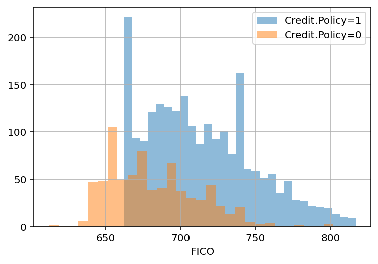

```python
loans[loans['credit.policy']==1]['fico'].hist(alpha=0.5,bins=29,label='Credit.Policy=1')
loans[loans['credit.policy']==0]['fico'].hist(alpha=0.5,bins=29,label='Credit.Policy=0')

plt.legend()
plt.xlabel('FICO')
plt.show()
```

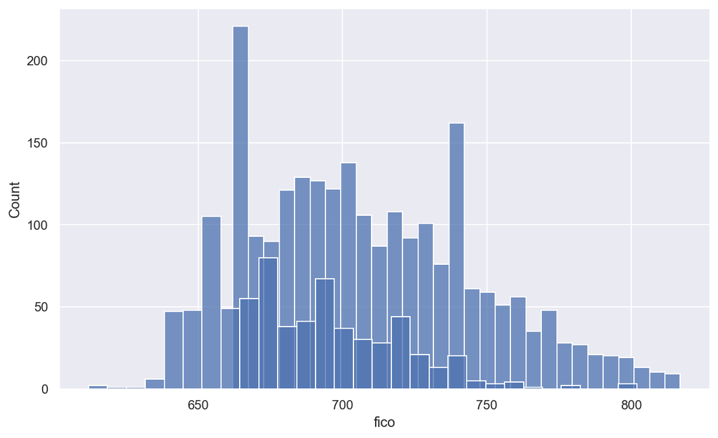

```python
# Alternatively you can use seaborn library to create the same histogram (although due to bin creation, it might look different!)
import seaborn as sns
sns.set(rc={"figure.figsize":(10, 6)})
sns.histplot(data=loans[loans['credit.policy']==1], x='fico', bins=29,label='Credit.Policy=1', kde=False)
sns.histplot(data=loans[loans['credit.policy']==0], x='fico', bins=29,label='Credit.Policy=0', kde=False)
```

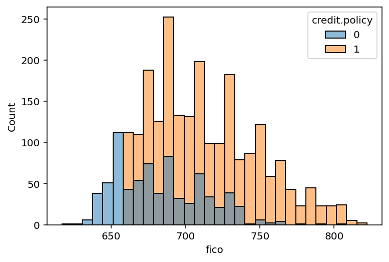

**Create another histogram for `not.fully.paid` column.**

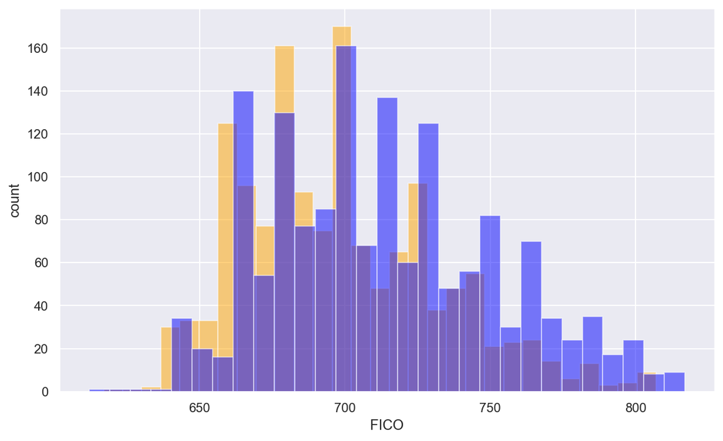

```python
loans[loans['not.fully.paid'] == 1]['fico'].hist(alpha=0.5, color='orange', bins=29, label='not.fully.paid=1')
loans[loans['not.fully.paid'] == 0]['fico'].hist(alpha=0.5, color='blue', bins=29, label='not.fully.paid=0')
plt.xlabel('FICO')
plt.ylabel('count')
```

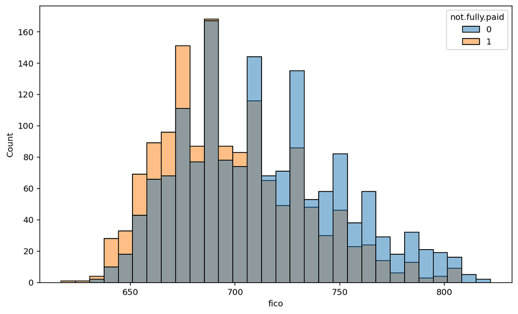

**Create a countplot (bar plot showing counts using seaborn) that shows the counts of loans by purpose, with the color hue defined by `not.fully.paid`**

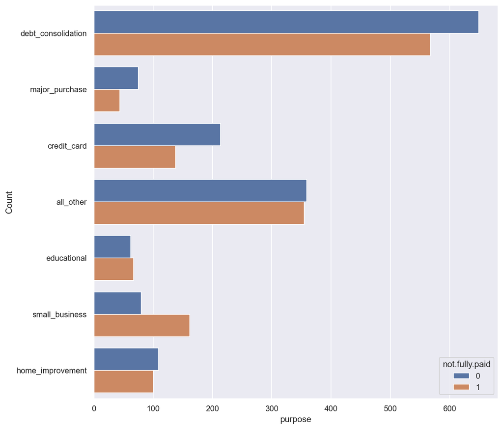

```python
sns.set(rc={"figure.figsize":(10, 10)})

sns.countplot(data=loans, y='purpose', hue='not.fully.paid')

plt.xlabel('purpose')
plt.ylabel('Count')

plt.show()
```

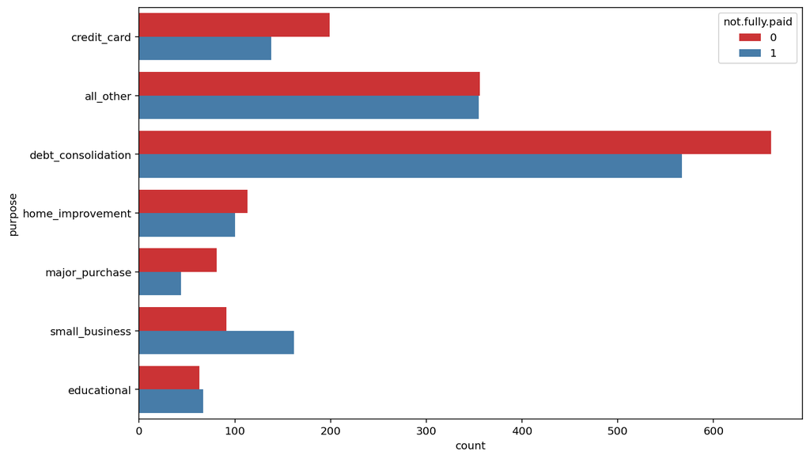

**Let's see the trend between FICO score and interest rate. Recreate the following jointplot.**

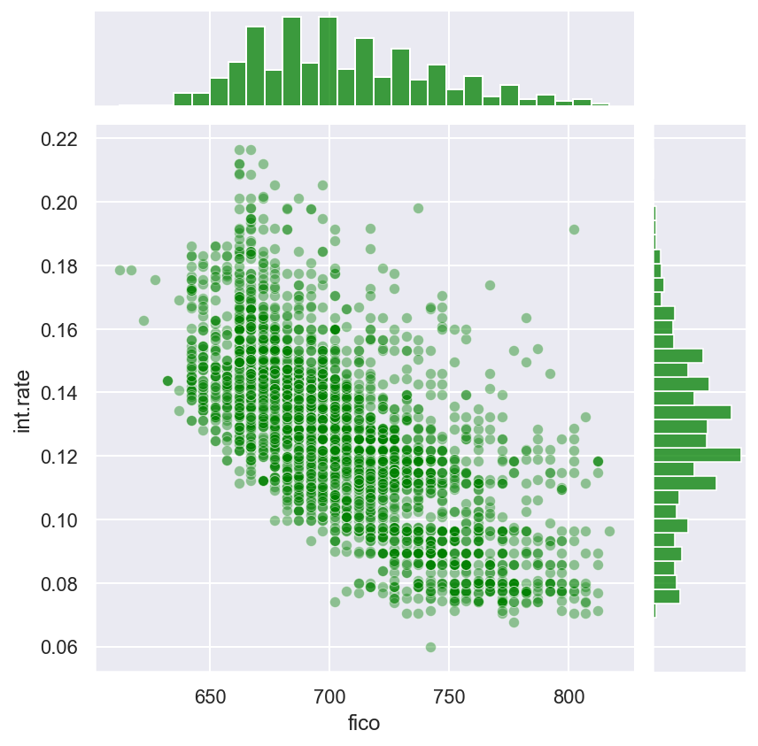

```python
sns.jointplot('fico', 'int.rate', data=loans, alpha=0.4, color='green')
```

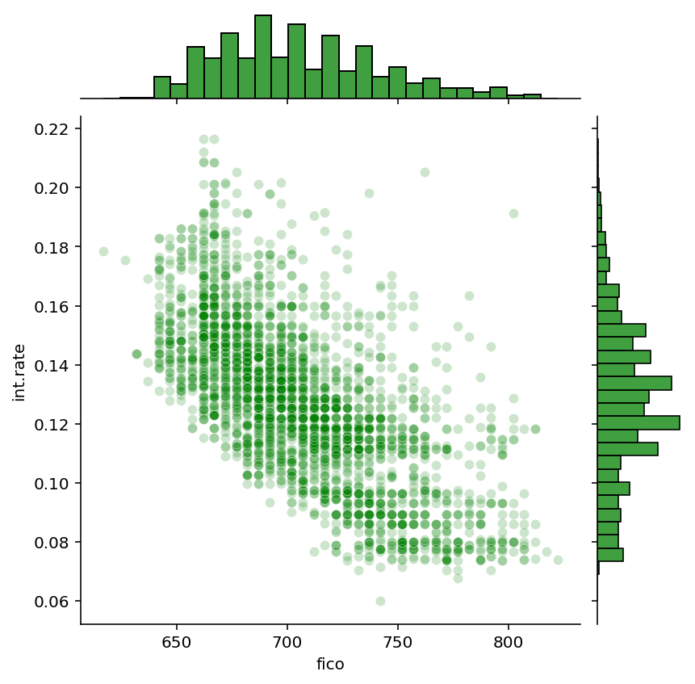

**Create the following lmplots to see if the trend differed between `not.fully.paid` and `int.rate`. Check the documentation for seaborn `lmplot()` if you can't figure out how to separate it into columns.**

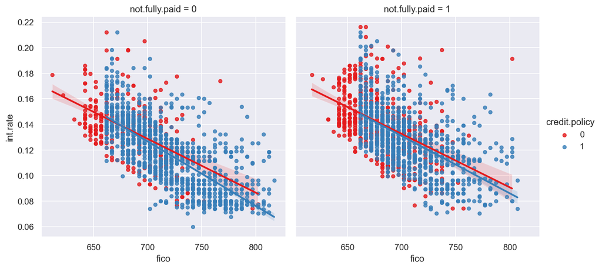

```python
sns.lmplot('fico', 'int.rate', data=loans, fit_reg= True, aspect=1, size =5, hue='credit.policy', col='not.fully.paid',palette="Set1",scatter_kws={"s": 20})
```

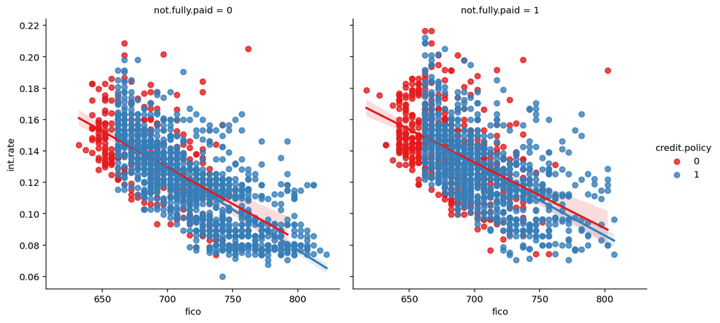

# Q3

## Setting up the Data

Let's get ready to set up our data for our models!

**This question has already been solved. You don't need to do anything. Just run the cells and continue.**

```python
loans.info()
```

```
<class 'pandas.core.frame.DataFrame'>
RangeIndex: 2981 entries, 0 to 2980
Data columns (total 14 columns):
 #   Column             Non-Null Count  Dtype
---  ------             --------------  -----
 0   credit.policy      2981 non-null   int64
 1   purpose            2981 non-null   object
 2   int.rate           2981 non-null   float64
 3   installment        2981 non-null   float64
 4   log.annual.inc     2981 non-null   float64
 5   dti                2981 non-null   float64
 6   fico               2981 non-null   int64
 7   days.with.cr.line  2981 non-null   float64
 8   revol.bal          2981 non-null   int64
 9   revol.util         2981 non-null   float64
 10  inq.last.6mths     2981 non-null   int64
 11  delinq.2yrs        2981 non-null   int64
 12  pub.rec            2981 non-null   int64
 13  not.fully.paid     2981 non-null   int64
dtypes: float64(6), int64(7), object(1)
memory usage: 326.2+ KB
```

## Categorical Features

Notice that the **purpose** column is of categorical type.

That means we need to transform them using dummy variables so sklearn will be able to understand them.

Let's do this in one step using pd.get_dummies().

> The same transformation needs to be aplied on the test set as well. The easiest way would be to merge train and test sets, and to split after the transformation.

```python
cat_feats = ['purpose']
```

```python
loans = pd.get_dummies(loans, columns=cat_feats, drop_first=False)
```

```python
loans.info()
```

```
<class 'pandas.core.frame.DataFrame'>
RangeIndex: 2981 entries, 0 to 2980
Data columns (total 20 columns):
 #   Column                      Non-Null Count  Dtype
---  ------                      --------------  -----
 0   credit.policy               2981 non-null   int64
 1   int.rate                    2981 non-null   float64
 2   installment                 2981 non-null   float64
 3   log.annual.inc              2981 non-null   float64
 4   dti                         2981 non-null   float64
 5   fico                        2981 non-null   int64
 6   days.with.cr.line           2981 non-null   float64
 7   revol.bal                   2981 non-null   int64
 8   revol.util                  2981 non-null   float64
 9   inq.last.6mths              2981 non-null   int64
 10  delinq.2yrs                 2981 non-null   int64
 11  pub.rec                     2981 non-null   int64
 12  not.fully.paid              2981 non-null   int64
 13  purpose_all_other           2981 non-null   uint8
 14  purpose_credit_card         2981 non-null   uint8
 15  purpose_debt_consolidation  2981 non-null   uint8
 16  purpose_educational         2981 non-null   uint8
 17  purpose_home_improvement    2981 non-null   uint8
 18  purpose_major_purchase      2981 non-null   uint8
 19  purpose_small_business      2981 non-null   uint8
dtypes: float64(6), int64(7), uint8(7)
memory usage: 323.3 KB
```

```python
loans.head()
```

|  | credit.policy | int.rate | installment | log.annual.inc | dti | fico | days.with.cr.line | revol.bal | revol.util | inq.last.6mths | delinq.2yrs | pub.rec | not.fully.paid | purpose_all_other | purpose_credit_card | purpose_debt_consolidation | purpose_educational | purpose_home_improvement | purpose_major_purchase | purpose_small_business |
| --- | --- | --- | --- | --- | --- | --- | --- | --- | --- | --- | --- | --- | --- | --- | --- | --- | --- | --- | --- | --- |
| 0 | 1 | 0.1183 | 231.94 | 10.348846 | 5.69 | 712 | 2460.958333 | 6955 | 63.8 | 1 | 0 | 0 | 0 | 0 | 0 | 1 | 0 | 0 | 0 | 0 |
| 1 | 1 | 0.0774 | 124.88 | 11.264464 | 7.17 | 792 | 6360.041667 | 168 | 0.7 | 0 | 0 | 0 | 0 | 0 | 0 | 0 | 0 | 0 | 1 | 0 |
| 2 | 1 | 0.1505 | 86.73 | 11.184421 | 16.30 | 667 | 3600.000000 | 16242 | 95.5 | 0 | 0 | 0 | 0 | 0 | 1 | 0 | 0 | 0 | 0 | 0 |
| 3 | 1 | 0.1284 | 403.42 | 10.736397 | 19.57 | 697 | 3450.041667 | 27261 | 87.4 | 1 | 0 | 0 | 0 | 0 | 0 | 1 | 0 | 0 | 0 | 0 |
| 4 | 1 | 0.1531 | 278.53 | 10.621327 | 8.20 | 662 | 1860.000000 | 7979 | 48.7 | 0 | 1 | 0 | 0 | 0 | 0 | 1 | 0 | 0 | 0 | 0 |

## Train Test Split

Now its time to split our data into a training set and a validation set!

The `not.fully.paid` variable is the one that we will try to predict.

**Use sklearn to split your data into a training set and a testing set as we've done in the past.**

```python
from sklearn.model_selection import train_test_split
```

```python
loans
```

|  | credit.policy | int.rate | installment | log.annual.inc | dti | fico | days.with.cr.line | revol.bal | revol.util | inq.last.6mths | delinq.2yrs | pub.rec | not.fully.paid | purpose_all_other | purpose_credit_card | purpose_debt_consolidation | purpose_educational | purpose_home_improvement | purpose_major_purchase | purpose_small_business |
| --- | --- | --- | --- | --- | --- | --- | --- | --- | --- | --- | --- | --- | --- | --- | --- | --- | --- | --- | --- | --- |
| 0 | 1 | 0.1183 | 231.94 | 10.348846 | 5.69 | 712 | 2460.958333 | 6955 | 63.8 | 1 | 0 | 0 | 0 | 0 | 0 | 1 | 0 | 0 | 0 | 0 |
| 1 | 1 | 0.0774 | 124.88 | 11.264464 | 7.17 | 792 | 6360.041667 | 168 | 0.7 | 0 | 0 | 0 | 0 | 0 | 0 | 0 | 0 | 0 | 1 | 0 |
| 2 | 1 | 0.1505 | 86.73 | 11.184421 | 16.30 | 667 | 3600.000000 | 16242 | 95.5 | 0 | 0 | 0 | 0 | 0 | 1 | 0 | 0 | 0 | 0 | 0 |
| 3 | 1 | 0.1284 | 403.42 | 10.736397 | 19.57 | 697 | 3450.041667 | 27261 | 87.4 | 1 | 0 | 0 | 0 | 0 | 0 | 1 | 0 | 0 | 0 | 0 |
| 4 | 1 | 0.1531 | 278.53 | 10.621327 | 8.20 | 662 | 1860.000000 | 7979 | 48.7 | 0 | 1 | 0 | 0 | 0 | 0 | 1 | 0 | 0 | 0 | 0 |
| ... | ... | ... | ... | ... | ... | ... | ... | ... | ... | ... | ... | ... | ... | ... | ... | ... | ... | ... | ... | ... |
| 2976 | 0 | 0.1797 | 364.99 | 10.762488 | 23.53 | 642 | 4252.041667 | 10226 | 63.9 | 1 | 1 | 0 | 0 | 0 | 0 | 1 | 0 | 0 | 0 | 0 |
| 2977 | 1 | 0.1316 | 202.63 | 11.156251 | 23.91 | 692 | 2130.000000 | 22713 | 43.1 | 1 | 0 | 0 | 0 | 0 | 0 | 1 | 0 | 0 | 0 | 0 |
| 2978 | 1 | 0.1148 | 263.75 | 10.491274 | 2.90 | 727 | 1800.000000 | 2980 | 31.7 | 1 | 0 | 0 | 0 | 0 | 0 | 1 | 0 | 0 | 0 | 0 |
| 2979 | 1 | 0.1442 | 859.57 | 12.611538 | 1.48 | 702 | 5279.958333 | 28367 | 66.5 | 2 | 1 | 0 | 0 | 0 | 0 | 0 | 0 | 1 | 0 | 0 |
| 2980 | 1 | 0.0894 | 381.26 | 11.512925 | 11.27 | 747 | 4649.958333 | 23270 | 41.0 | 1 | 0 | 0 | 0 | 0 | 0 | 0 | 0 | 0 | 1 | 0 |

2981 rows × 20 columns

```python
X = loans.drop('not.fully.paid',axis=1)
y = loans['not.fully.paid']
X_train, X_test, y_train, y_test = train_test_split(X, y, test_size=0.40, random_state=RANDOM_STATE)
X_val, X_test, y_val, y_test = train_test_split(X_test, y_test, test_size=0.50, random_state=RANDOM_STATE)
```

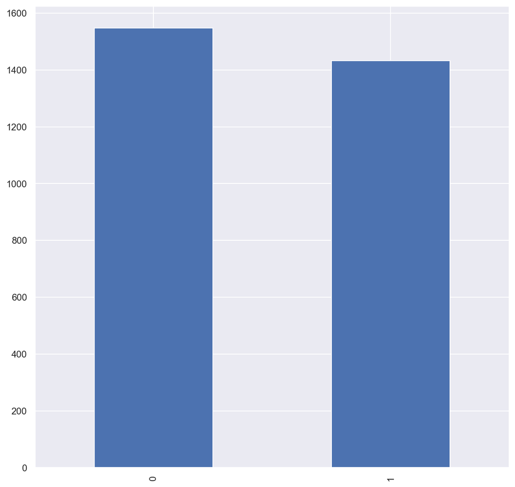

```python
y.value_counts().plot(kind='bar')
```

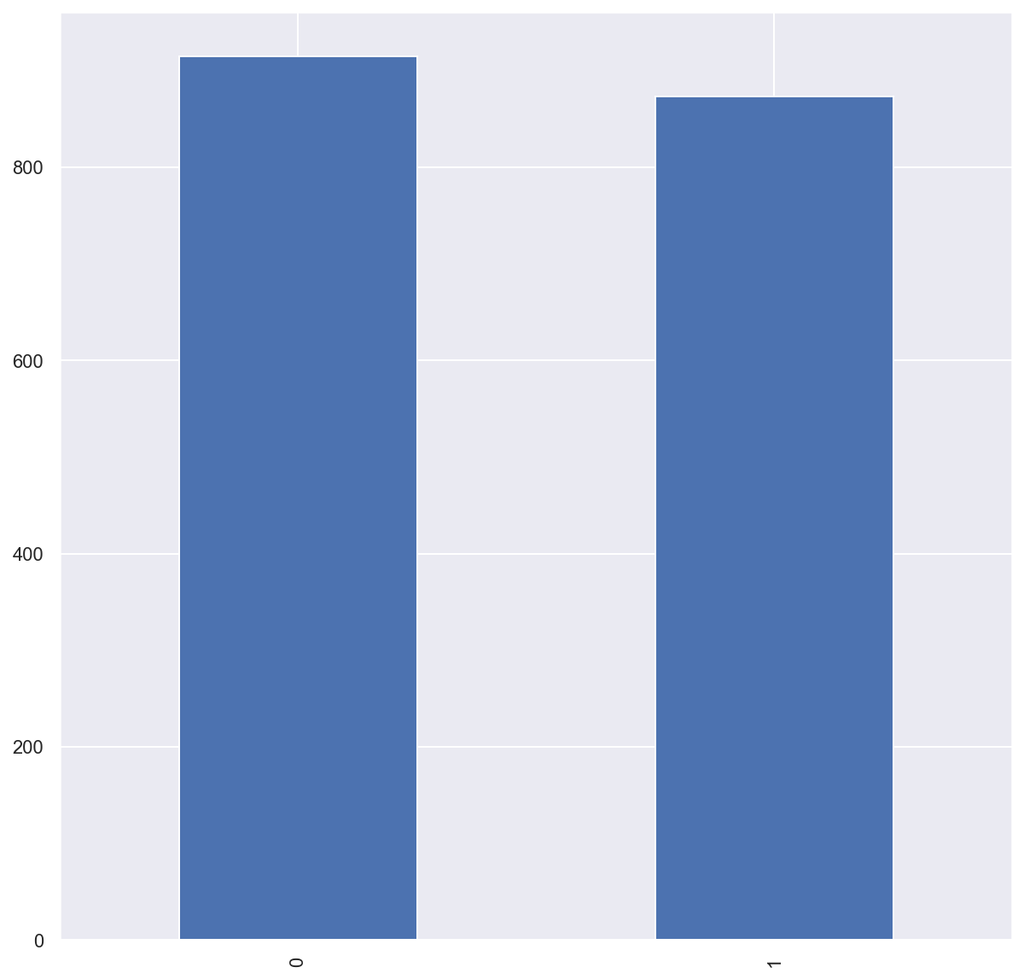

```python
y_train.value_counts().plot(kind='bar')
```

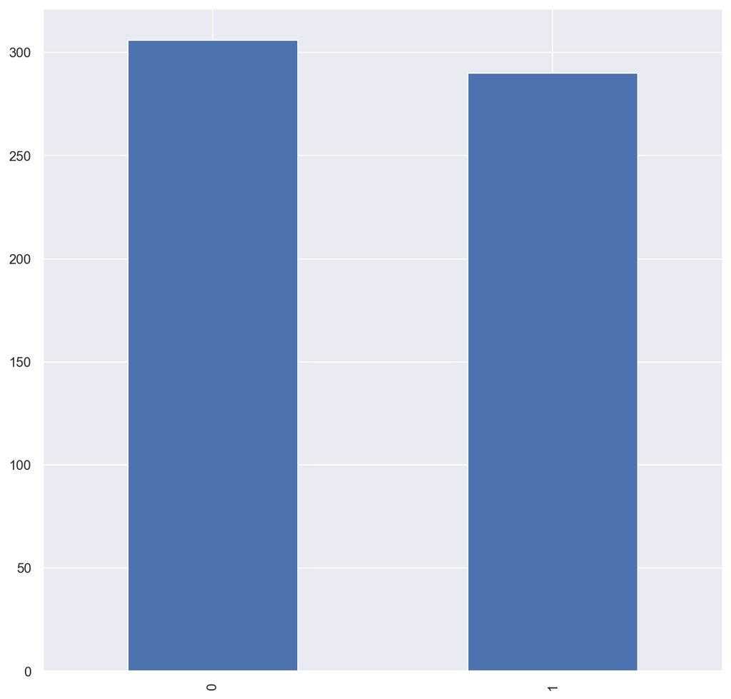

```python
y_val.value_counts().plot(kind='bar')
```

> NOTE:

When asked to provide the performance metrics you can use the confusion matrix or the methods in `sklearn.metrics`.  
**Performance metrics** (at the very least):

- Recall (Sensitivity)
- Specificity
- Precision
- Balanced Accuracy
- F1 Score

Grid Search:

- https://scikit-learn.org/stable/modules/generated/sklearn.model_selection.GridSearchCV.html

# Q4

## Decision Tree Model

Let's start by training a single decision tree first!

1. Default decision tree:
   - Initiate the Decision Tree classifier from the sklearn library. Keep all parameters with their default values. (No need to specify anything)
   - Fit the model
   - Make predictions
   - Calculate accuracy score. What are the **training** and **validation** accuracies of the model?
   - Create confusion matrix
   - Provide the performance metrics for the **validation** set.
1. Using the training data perform hyper-parameter tuning. Use an appropriate metric for scoring (f1 is generally good).
   - Try several values for the `min_samples_split` hyper-parameter and apply cross validation (`GridSearchCV`) to find the best value.
     - Using the best model provide the performance metrics for the validation set.
   - Try several values for the `max_depth` hyper-parameter and apply cross validation (`GridSearchCV`) to find the best value.
     - Using the best model provide the performance metrics for the validation set.
   - Perform grid search (`GridSearchCV`) where you check for `min_samples_split` and `max_depth`.
     - Using the best model provide the performance metrics for the validation set.
1. Create a chart showing the feature importances based on the best model obtained.

**Default decision tree**

```python
# Import DecisionTreeClassifier
from sklearn.tree import DecisionTreeClassifier
```

```python
# code
clf = DecisionTreeClassifier(random_state=123) #initiate
clf.fit(X_train, y_train) #fit
```

```
DecisionTreeClassifier(random_state=123)
```

```python
#predictions
y_pred_val = clf.predict(X_val) #for validation set
y_pred_train = clf.predict(X_train) #for training set
```

```python
#accuracy scores
accuracy_val = accuracy_score(y_val, y_pred_val) #for validation set
print(f"Accuracy for validation set: {accuracy_val:.2f}")

accuracy_train = accuracy_score(y_train, y_pred_train) #for validation set
print(f"Accuracy for training set: {accuracy_train:.2f}")
```

```
Accuracy for validation set: 0.57
Accuracy for training set: 1.00
```

```python
#confusion matrix
conf_matrix = confusion_matrix(y_val, y_pred_val)
print(conf_matrix)
```

```
[[166 140]
 [117 173]]
```

```python
#precision score
precision = precision_score(y_val, y_pred_val)

#recall score
recall = recall_score(y_val, y_pred_val)

#f1 score
f1 = f1_score(y_val, y_pred_val)

print(precision,"is the Precision")
print()
print(recall,"is the Recall")
print()
print(f1,"is the F1 score")
```

```
0.5527156549520766 is the Precision

0.596551724137931 is the Recall

0.5737976782752902 is the F1 score
```

```python
report = classification_report(y_val, y_pred_val, output_dict=True)

#Specificity
specificity = report['0']['recall']
print(specificity, "is the Specificity")

#False positive rate
false = 1 - specificity
print(false,"is the False positive rate")
```

```
0.5424836601307189 is the Specificity
0.4575163398692811 is the False positive rate
```

**Training data hyper-parameter tuning**

```python
#min_samples_split
param_grid = {
    'min_samples_split': [2, 5, 10, 15, 20]
}
grid_search = GridSearchCV(estimator=clf, param_grid=param_grid, cv=5, n_jobs=-1, scoring='f1')
grid_search.fit(X_train, y_train)
best_params = grid_search.best_params_
print("Best Hyperparameters:", best_params)
```

```
Best Hyperparameters: {'min_samples_split': 5}
```

```python
best_clf = DecisionTreeClassifier(**best_params, random_state=123)

# Fit the optimized model to the training data
best_clf.fit(X_train, y_train)

# Make predictions on the test set
y_pred_optimized = best_clf.predict(X_val)

# Calculate accuracy after hyperparameter tuning
accuracy_optimized = accuracy_score(y_val, y_pred_optimized)
print(f"Accuracy (Optimized): {accuracy_optimized:.5f}")

# Generate a classification report
report = classification_report(y_val, y_pred_optimized)
print("Classification Report:\n", report)
```

```
Accuracy (Optimized): 0.55201
Classification Report:
               precision    recall  f1-score   support

           0       0.57      0.55      0.56       306
           1       0.54      0.56      0.55       290

    accuracy                           0.55       596
   macro avg       0.55      0.55      0.55       596
weighted avg       0.55      0.55      0.55       596
```

```python
#max_depth
param_grid = {
    'max_depth': [None, 5, 10, 15]
}
grid_search = GridSearchCV(estimator=clf, param_grid=param_grid, cv=5, n_jobs=-1, scoring='f1')
grid_search.fit(X_train, y_train)
best_params = grid_search.best_params_
print("Best Hyperparameters:", best_params)
```

```
Best Hyperparameters: {'max_depth': 10}
```

```python
best_clf = DecisionTreeClassifier(**best_params, random_state=123)

# Fit the optimized model to the training data
best_clf.fit(X_train, y_train)

# Make predictions on the test set
y_pred_optimized = best_clf.predict(X_val)

# Calculate accuracy after hyperparameter tuning
accuracy_optimized = accuracy_score(y_val, y_pred_optimized)
print(f"Accuracy (Optimized): {accuracy_optimized:.5f}")

# Generate a classification report
report = classification_report(y_val, y_pred_optimized)
print("Classification Report:\n", report)
```

```
Accuracy (Optimized): 0.58221
Classification Report:
               precision    recall  f1-score   support

           0       0.59      0.60      0.60       306
           1       0.57      0.56      0.57       290

    accuracy                           0.58       596
   macro avg       0.58      0.58      0.58       596
weighted avg       0.58      0.58      0.58       596
```

```python
#min_samples_split and max _depth
param_grid = {
    'min_samples_split': [2, 5, 10, 15, 20],
    'max_depth': [None, 5, 10, 15]
}
grid_search = GridSearchCV(estimator=clf, param_grid=param_grid, cv=5, n_jobs=-1, scoring='f1')
grid_search.fit(X_train, y_train)
best_params = grid_search.best_params_
print("Best Hyperparameters:", best_params)
```

```
Best Hyperparameters: {'max_depth': 10, 'min_samples_split': 20}
```

```python
best_clf = DecisionTreeClassifier(**best_params, random_state=123)

# Fit the optimized model to the training data
best_clf.fit(X_train, y_train)

# Make predictions on the test set
y_pred_optimized = best_clf.predict(X_val)

# Calculate accuracy after hyperparameter tuning
accuracy_optimized = accuracy_score(y_val, y_pred_optimized)
print(f"Accuracy (Optimized): {accuracy_optimized:.5f}")

# Generate a classification report
report = classification_report(y_val, y_pred_optimized)
print("Classification Report:\n", report)
```

```
Accuracy (Optimized): 0.58725
Classification Report:
               precision    recall  f1-score   support

           0       0.59      0.62      0.61       306
           1       0.58      0.55      0.57       290

    accuracy                           0.59       596
   macro avg       0.59      0.59      0.59       596
weighted avg       0.59      0.59      0.59       596
```

**Chart showing the feature importances based on the best model obtained**

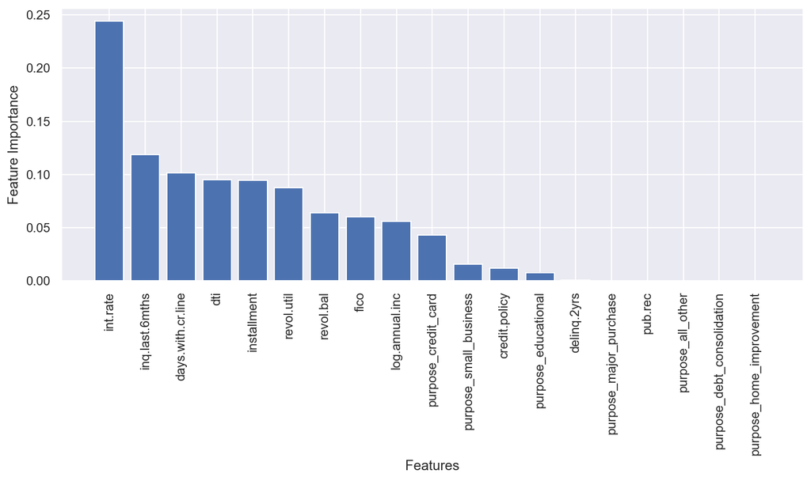

```python
feature_importances = best_clf.feature_importances_
feature_names = X_train.columns
sorted_indices = feature_importances.argsort()[::-1]

plt.figure(figsize=(10, 6))
plt.bar(range(len(feature_importances)), feature_importances[sorted_indices])
plt.xticks(range(len(feature_importances)), [feature_names[i] for i in sorted_indices], rotation=90)
plt.xlabel("Features")
plt.ylabel("Feature Importance")
plt.tight_layout()
plt.show()
```

# Q5

## Random Forest model

1. Default Random Forest Classifier:
   - Initiate the Random Forest Classifier from the sklearn library. Keep all parameters with their default values. (No need to specify anything)
   - Fit the model
   - Make predictions
   - Calculate accuracy score. What are the **training** and **validation** accuracies of the model?
   - Create confusion matrix
   - Provide the performance metrics for the **validation** set.
1. Using the training data perform hyper-parameter tuning. Use an appropriate metric for scoring (f1 is generally good).
   - Perform grid search (`GridSearchCV`) where you check for `min_samples_split`, `max_depth`, and `n_estimators`.
     - Using the best model provide the performance metrics for the validation set.
2. Create a chart showing the feature importances based on the best model obtained.

**Default Random Forest**

```python
from sklearn.ensemble import RandomForestClassifier
```

```python
# code
rf = RandomForestClassifier()
rf.fit(X_train, y_train)
```

```
RandomForestClassifier()
```

```python
#predictions
y_pred_val2 = rf.predict(X_val) #for validation set
y_pred_train2 = rf.predict(X_train) #for training set
```

```python
#accuracy scores
accuracy_val2 = accuracy_score(y_val, y_pred_val2) #for validation set
print(f"Accuracy for validation set: {accuracy_val2:.2f}")

accuracy_train2 = accuracy_score(y_train, y_pred_train2) #for validation set
print(f"Accuracy for training set: {accuracy_train2:.2f}")
```

```
Accuracy for validation set: 0.59
Accuracy for training set: 1.00
```

```python
#confusion matrix
conf_matrix2 = confusion_matrix(y_val, y_pred_val2)
print(conf_matrix2)
```

```
[[174 132]
 [113 177]]
```

```python
#precision score
precision2 = precision_score(y_val, y_pred_val2)

#recall score
recall2 = recall_score(y_val, y_pred_val2)

#f1 score
f1_2 = f1_score(y_val, y_pred_val2)

print(precision2,"is the Precision")
print()
print(recall2,"is the Recall")
print()
print(f1_2,"is the F1 score")
```

```
0.5728155339805825 is the Precision

0.6103448275862069 is the Recall

0.5909849749582637 is the F1 score
```

```python
report2 = classification_report(y_val, y_pred_val2, output_dict=True)

#Specificity
specificity2 = report2['0']['recall']
print(specificity2, "is the Specificity")

#False positive rate
false2 = 1 - specificity2
print(false2,"is the False positive rate")
```

```
0.5686274509803921 is the Specificity
0.43137254901960786 is the False positive rate
```

**Training data hyper-parameter tuning**

```python
param_grid_rf = {
    'min_samples_split': [2, 5, 10, 15],
    'max_depth': [None, 10, 20, 30, 40],
    'n_estimators': [50, 100, 200, 300]
}
grid_search_rf = GridSearchCV(rf, param_grid_rf, scoring='f1', cv=5, n_jobs=-1)
grid_search_rf.fit(X_train, y_train)

best_params_rf = grid_search_rf.best_params_

print("Best Hyperparameters:", best_params_rf)
```

```
Best Hyperparameters: {'max_depth': 20, 'min_samples_split': 15, 'n_estimators': 200}
```

```python
best_rf = RandomForestClassifier(**best_params_rf, random_state=123)

# Fit the optimized model to the training data
best_rf.fit(X_train, y_train)

# Make predictions on the test set
y_pred_optimized2 = best_rf.predict(X_val)

# Calculate accuracy after hyperparameter tuning
accuracy_optimized2 = accuracy_score(y_val, y_pred_optimized2)
print(f"Accuracy (Optimized): {accuracy_optimized2:.5f}")

# Generate a classification report
report_rf = classification_report(y_val, y_pred_optimized2)
print("Classification Report:\n", report_rf)
```

```
Accuracy (Optimized): 0.61242
Classification Report:
               precision    recall  f1-score   support

           0       0.63      0.58      0.61       306
           1       0.59      0.64      0.62       290

    accuracy                           0.61       596
   macro avg       0.61      0.61      0.61       596
weighted avg       0.61      0.61      0.61       596
```

**Chart showing the feature importances based on the best model obtained**

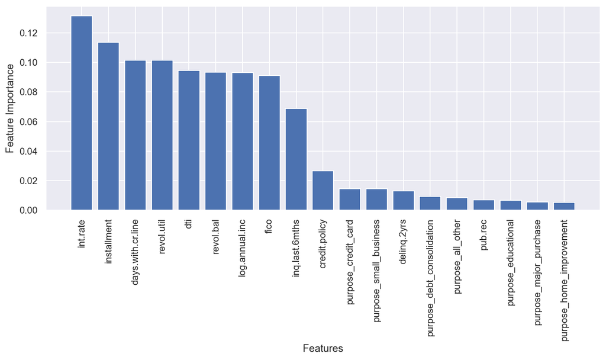

```python
feature_importances2 = best_rf.feature_importances_
feature_names2 = X_train.columns
sorted_indices2 = feature_importances2.argsort()[::-1]

plt.figure(figsize=(10, 6))
plt.bar(range(len(feature_importances2)), feature_importances2[sorted_indices2])
plt.xticks(range(len(feature_importances2)), [feature_names2[i] for i in sorted_indices2], rotation=90)
plt.xlabel("Features")
plt.ylabel("Feature Importance")
plt.tight_layout()
plt.show()
```

# Q6

## Adaboost model

1. Default Adaboost classifier:
   - Initiate the Adaboost classifier from the sklearn library. Keep all parameters with their default values. (No need to specify anything)
   - Fit the model
   - Make predictions
   - Calculate accuracy score. What are the **training** and **validation** accuracies of the model?
   - Create confusion matrix
   - Provide the performance metrics for the **validation** set.
1. Using the training data perform hyper-parameter tuning. Use an appropriate metric for scoring (f1 is generally good).
   - Perform grid search (`GridSearchCV`) where you check for `learning_rate`, and `n_estimators`.
     - Using the best model provide the performance metrics for the validation set.
2. Create a chart showing the feature importances based on the best model obtained.

**Default Adaboost classifier**

```python
from sklearn.ensemble import AdaBoostClassifier
```

```python
# YOUR CODE
ada = AdaBoostClassifier()
ada.fit(X_train, y_train)
```

```
AdaBoostClassifier()
```

```python
#predictions
y_pred_val3 = ada.predict(X_val) #for validation set
y_pred_train3 = ada.predict(X_train) #for training set
```

```python
#accuracy scores
accuracy_val3 = accuracy_score(y_val, y_pred_val3) #for validation set
print(f"Accuracy for validation set: {accuracy_val3:.2f}")

accuracy_train3 = accuracy_score(y_train, y_pred_train3) #for validation set
print(f"Accuracy for training set: {accuracy_train3:.2f}")
```

```
Accuracy for validation set: 0.59
Accuracy for training set: 0.67
```

```python
#confusion matrix
conf_matrix3 = confusion_matrix(y_val, y_pred_val3)
print(conf_matrix3)
```

```
[[177 129]
 [118 172]]
```

```python
#precision score
precision3 = precision_score(y_val, y_pred_val3)

#recall score
recall3 = recall_score(y_val, y_pred_val3)

#f1 score
f1_3 = f1_score(y_val, y_pred_val3)

print(precision3,"is the Precision")
print()
print(recall3,"is the Recall")
print()
print(f1_3,"is the F1 score")
```

```
0.5714285714285714 is the Precision

0.593103448275862 is the Recall

0.5820642978003383 is the F1 score
```

```python
report3 = classification_report(y_val, y_pred_val3, output_dict=True)

#Specificity
specificity3 = report3['0']['recall']
print(specificity3, "is the Specificity")

#False positive rate
false3 = 1 - specificity3
print(false3,"is the False positive rate")
```

```
0.5784313725490197 is the Specificity
0.42156862745098034 is the False positive rate
```

**Training data hyper-parameter tuning**

```python
param_grid_ada = {
    'learning_rate': [0.01, 0.1, 0.5, 1.0],
    'n_estimators': [50, 100, 200, 300]
}
grid_search_ada = GridSearchCV(ada, param_grid_ada, scoring='f1', cv=5, n_jobs=-1)
grid_search_ada.fit(X_train, y_train)

best_params_ada = grid_search_ada.best_params_

print("Best Hyperparameters:", best_params_ada)
```

```
Best Hyperparameters: {'learning_rate': 0.01, 'n_estimators': 50}
```

```python
best_ada = AdaBoostClassifier(**best_params_ada, random_state=123)

# Fit the optimized model to the training data
best_ada.fit(X_train, y_train)

# Make predictions on the test set
y_pred_optimized3 = best_ada.predict(X_val)

# Calculate accuracy after hyperparameter tuning
accuracy_optimized3 = accuracy_score(y_val, y_pred_optimized3)
print(f"Accuracy (Optimized): {accuracy_optimized3:.5f}")

# Generate a classification report
report_ada = classification_report(y_val, y_pred_optimized3)
print("Classification Report:\n", report_ada)
```

```
Accuracy (Optimized): 0.58221
Classification Report:
               precision    recall  f1-score   support

           0       0.64      0.42      0.51       306
           1       0.55      0.76      0.64       290

    accuracy                           0.58       596
   macro avg       0.60      0.59      0.57       596
weighted avg       0.60      0.58      0.57       596
```

**Chart showing the feature importances based on the best model obtained**

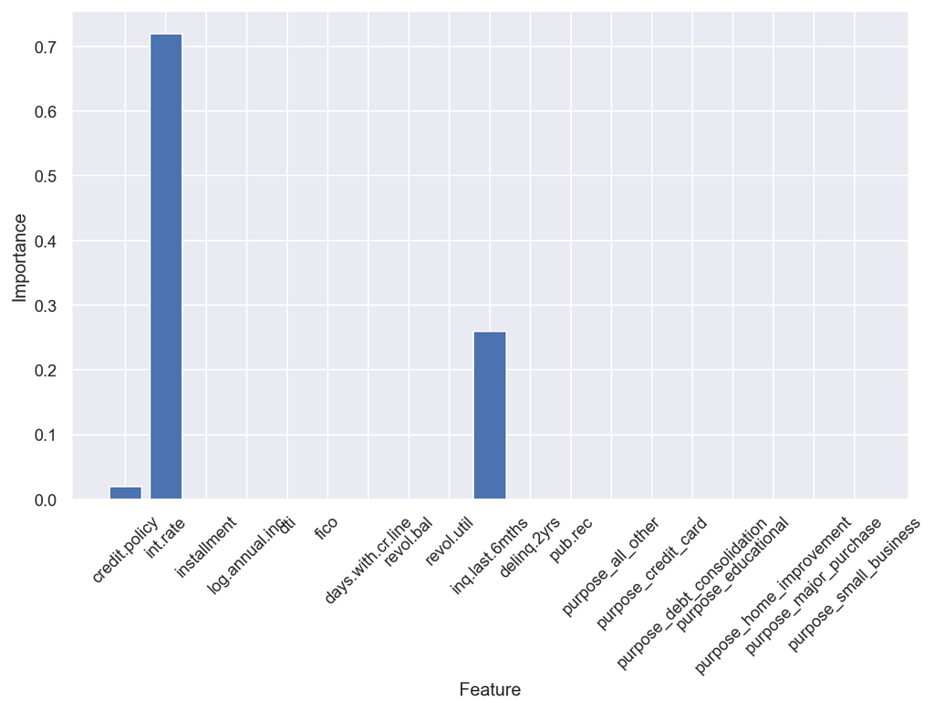

```python
feature_importances3 = best_ada.feature_importances_

plt.figure(figsize=(10, 6))
plt.bar(X_train.columns, feature_importances3)
plt.xlabel('Feature')
plt.ylabel('Importance')
plt.xticks(rotation=45)
plt.show()
```

# Q7

## Gradient Boosting Machine

1. Default Gradient Boosting classifier:
   - Initiate the Gradient Boosting classifier from the sklearn library. Keep all parameters with their default values. (No need to specify anything)
   - Fit the model
   - Make predictions
   - Calculate accuracy score. What are the **training** and **validation** accuracies of the model?
   - Create confusion matrix
   - Provide the performance metrics for the **validation** set.
1. Using the training data perform hyper-parameter tuning. Use an appropriate metric for scoring (f1 is generally good).
   - Perform grid search (`GridSearchCV`) where you check for `learning_rate`, and `n_estimators`.
     - Using the best model provide the performance metrics for the validation set.
2. Create a chart showing the feature importances based on the best model obtained.

**Default Gradient Boosting classifier**

```python
from sklearn.ensemble import GradientBoostingClassifier
```

```python
# YOUR CODE
gb = GradientBoostingClassifier()
gb.fit(X_train, y_train)
```

```
GradientBoostingClassifier()
```

```python
#predictions
y_pred_val4 = gb.predict(X_val) #for validation set
y_pred_train4 = gb.predict(X_train) #for training set
```

```python
#accuracy scores
accuracy_val4 = accuracy_score(y_val, y_pred_val4) #for validation set
print(f"Accuracy for validation set: {accuracy_val4:.2f}")

accuracy_train4 = accuracy_score(y_train, y_pred_train4) #for validation set
print(f"Accuracy for training set: {accuracy_train4:.2f}")
```

```
Accuracy for validation set: 0.61
Accuracy for training set: 0.80
```

```python
#confusion matrix
conf_matrix4 = confusion_matrix(y_val, y_pred_val4)
print(conf_matrix4)
```

```
[[193 113]
 [119 171]]
```

```python
#precision score
precision4 = precision_score(y_val, y_pred_val4)

#recall score
recall4 = recall_score(y_val, y_pred_val4)

#f1 score
f1_4 = f1_score(y_val, y_pred_val4)

print(precision4,"is the Precision")
print()
print(recall4,"is the Recall")
print()
print(f1_4,"is the F1 score")
```

```
0.602112676056338 is the Precision

0.5896551724137931 is the Recall

0.5958188153310104 is the F1 score
```

```python
report4 = classification_report(y_val, y_pred_val4, output_dict=True)

#Specificity
specificity4 = report4['0']['recall']
print(specificity4, "is the Specificity")

#False positive rate
false4 = 1 - specificity4
print(false4,"is the False positive rate")
```

```
0.630718954248366 is the Specificity
0.369281045751634 is the False positive rate
```

**Training data hyper-parameter tuning**

```python
param_grid_gb = {
    'learning_rate': [0.01, 0.1, 0.5, 1.0],
    'n_estimators': [50, 100, 200, 300]
}
grid_search_gb = GridSearchCV(gb, param_grid_gb, scoring='f1', cv=5, n_jobs=-1)
grid_search_gb.fit(X_train, y_train)

best_params_gb = grid_search_gb.best_params_

print("Best Hyperparameters:", best_params_gb)
```

```
Best Hyperparameters: {'learning_rate': 0.1, 'n_estimators': 100}
```

```python
best_gb = GradientBoostingClassifier(**best_params_gb, random_state=123)

# Fit the optimized model to the training data
best_gb.fit(X_train, y_train)

# Make predictions on the test set
y_pred_optimized4 = best_gb.predict(X_val)

# Calculate accuracy after hyperparameter tuning
accuracy_optimized4 = accuracy_score(y_val, y_pred_optimized4)
print(f"Accuracy (Optimized): {accuracy_optimized4:.5f}")

# Generate a classification report
report_gb = classification_report(y_val, y_pred_optimized4)
print("Classification Report:\n", report_gb)
```

```
Accuracy (Optimized): 0.61074
Classification Report:
               precision    recall  f1-score   support

           0       0.62      0.63      0.62       306
           1       0.60      0.59      0.60       290

    accuracy                           0.61       596
   macro avg       0.61      0.61      0.61       596
weighted avg       0.61      0.61      0.61       596
```

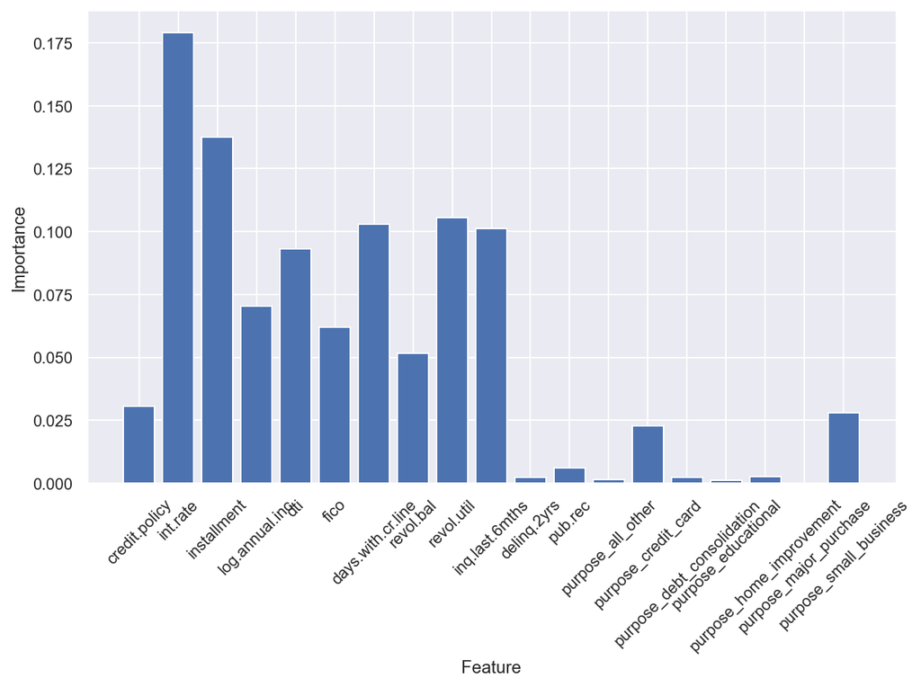

```python
feature_importances_4 = best_gb.feature_importances_

plt.figure(figsize=(10, 6))
plt.bar(X_train.columns, feature_importances_4)
plt.xlabel('Feature')
plt.ylabel('Importance')
plt.xticks(rotation=45)
plt.show()
```

# Q8 (15 points)

- Using one or more of the Decision Tree, Random Forest, Adaboost, and Gradient Boosting classifer models:
  - Think of other ways of improving the recall and F1-score and list at least two possibilities.
  - Implement both of the methods you proposed.
  - Is the model F1-score increasing?

For Decision Tree, we can improve recall and F1 score by **Pruning** and **Handling Class Imbalance**

```python
#YOUR CODE
clf_pruned = DecisionTreeClassifier(random_state=123, ccp_alpha=0.01)

#Fit the model
clf_pruned.fit(X_train, y_train)

#predictions
y_pred_val_pruned = clf_pruned.predict(X_val)

#metrics
recall_pruned = recall_score(y_val, y_pred_val_pruned)
f1_pruned = f1_score(y_val, y_pred_val_pruned)

print(f"Recall after pruning: {recall_pruned:.2f}")
print(f"F1-score after pruning: {f1_pruned:.2f}")
```

```
Recall after pruning: 0.92
F1-score after pruning: 0.67
```

```python
!pip install imbalanced-learn
from imblearn.over_sampling import SMOTE

sm = SMOTE(random_state=123)
X_res, y_res = sm.fit_resample(X_train, y_train)

clf.fit(X_res, y_res)

#predictions
y_pred_val_res = clf.predict(X_val)

#metrics
recall_res = recall_score(y_val, y_pred_val_res)
f1_res = f1_score(y_val, y_pred_val_res)

print(f"Recall after resampling: {recall_res:.2f}")
print(f"F1-score after resampling: {f1_res:.2f}")
```

```
Recall after resampling: 0.59
F1-score after resampling: 0.58
```

We can see that Pruning is increasing both Recall and F1 Score. And F1 score is slightly incresing by Handling Class Imbalance

# Q9 (15 points)

- Choose the best fitted model for each of the classifiers (1 model for each of Decision Tree, Random Forest, Adaboost, and Gradient Boosting)
- Create a table summarizing results on the **test set**:
  - Create confusion matrix for each model
  - Provide the performance metrics on the test set for each model.

Which one is the winner among all?

```python
dt9 = best_clf.predict(X_test)
dt9_accuracy = accuracy_score(y_test, dt9)
dt9_precision = precision_score(y_test, dt9)
dt9_recall = recall_score(y_test, dt9)
dt9_f1 = f1_score(y_test, dt9)

print("For Decision Tree")
print(dt9_accuracy,"is the Accuracy")
print(dt9_precision,"is the Precision")
print(dt9_recall,"is the Recall")
print(dt9_f1,"is the F1 Score")
print()

rf9 = best_rf.predict(X_test)
rf9_accuracy = accuracy_score(y_test, rf9)
rf9_precision = precision_score(y_test, rf9)
rf9_recall = recall_score(y_test, rf9)
rf9_f1 = f1_score(y_test, rf9)

print("For Random Forest")
print(rf9_accuracy,"is the Accuracy")
print(rf9_precision,"is the Precision")
print(rf9_recall,"is the Recall")
print(rf9_f1,"is the F1 Score")
print()

ada9 = best_ada.predict(X_test)
ada9_accuracy = accuracy_score(y_test, ada9)
ada9_precision = precision_score(y_test, ada9)
ada9_recall = recall_score(y_test, ada9)
ada9_f1 = f1_score(y_test, ada9)

print("For ADA")
print(ada9_accuracy,"is the Accuracy")
print(ada9_precision,"is the Precision")
print(ada9_recall,"is the Recall")
print(ada9_f1,"is the F1 Score")
print()


gb9 = best_gb.predict(X_test)
gb9_accuracy = accuracy_score(y_test, gb9)
gb9_precision = precision_score(y_test, gb9)
gb9_recall = recall_score(y_test, gb9)
gb9_f1 = f1_score(y_test, gb9)


print("For GB")
print(gb9_accuracy,"is the Accuracy")
print(gb9_precision,"is the Precision")
print(gb9_recall,"is the Recall")
print(gb9_f1,"is the F1 Score")
```

```
For Decision Tree
0.5745393634840871 is the Accuracy
0.5310077519379846 is the Precision
0.5074074074074074 is the Recall
0.5189393939393939 is the F1 Score

For Random Forest
0.6164154103852596 is the Accuracy
0.5729537366548043 is the Precision
0.5962962962962963 is the Recall
0.5843920145190563 is the F1 Score

For ADA
0.5728643216080402 is the Accuracy
0.5203252032520326 is the Precision
0.7111111111111111 is the Recall
0.6009389671361504 is the F1 Score

For GB
0.6063651591289783 is the Accuracy
0.5670498084291188 is the Precision
0.5481481481481482 is the Recall
0.5574387947269303 is the F1 Score
```

Random Forest has the best accuracy